# Statistical Inference Course Project

Peng Wu

24 February 2017

## Overview

This project will investigate the exponential distribution with R and compare it with the Central Limit Theorem. We will simulate the randomly generate 1000 set of 40 numbers out of a exponential distribution. We will show that the simulation mean and variance of the mean of 40 exponetials are very close to the theoretical mean and variance derived by Central Limit Theorem.

### Simulation

The exponential distribution can be simulated in R with rexp(n,lambda) where lambda s the rate parameter. The mean of exponential distribution is 1/lambda and the standard deviation is also 1/lambda. Set lambda = 0.2 for all of the simulations. We will investigate the distribution of averages of 40 exponentials. We will do 1000 simulations.

First of all, load necessary package.

```r
library(ggplot2)
```

Set seed for reproducability.

```r
set.seed(25)
```

Execute simulation.

```r
lambda <- 0.2
n <- 40
times <- 1000
sml <- replicate(times, rexp(n,lambda))
```

### Task 1: Show the sample mean and compare it to the theoretical mean of the distribution.

Calculate the means of the each of the 1000 simulations.

```r
mns <- apply(sml,2,mean)
```

Calculate the mean of the 1000 means.

```r
sml.mean <- mean(mns)
sml.mean
```

```
## [1] 4.998511
```

Calculate the theoretical mean.

```r
theory.mean <- 1/lambda
theory.mean
```

```
## [1] 5
```

Plot the result.

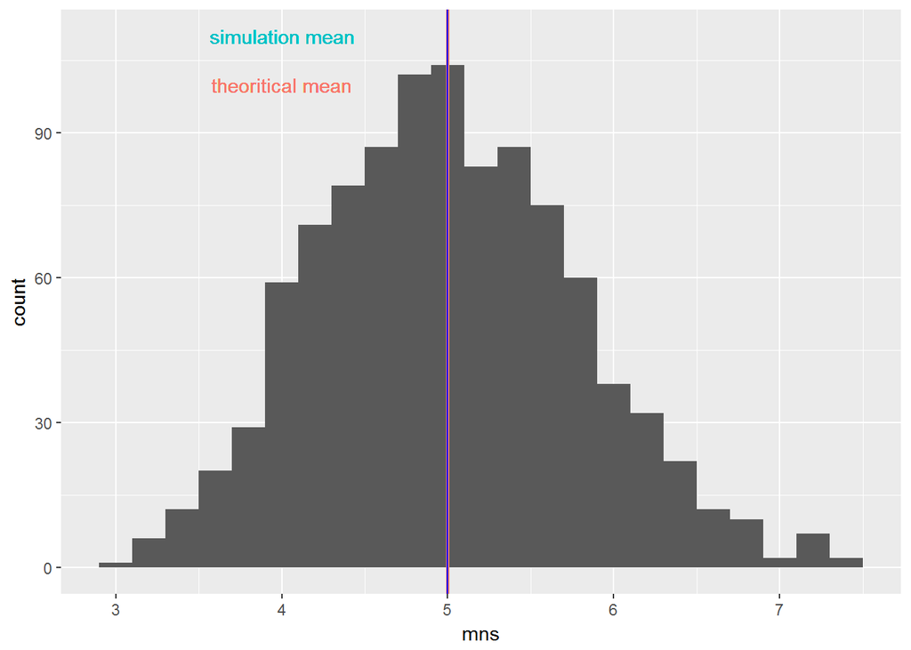

```r
df.mns <- data.frame(mns)
ggplot(df.mns,mapping = aes(x = mns)) +
        geom_histogram(stat = "bin",binwidth = 0.2)  +
        geom_vline(xintercept = sml.mean,color = "salmon",size = 1) +
        geom_vline(xintercept = theory.mean, color = "blue") +
        geom_text(aes(4,110,label = "simulation mean",color = "salmon")) +
        geom_text(aes(4,100,label = "theoritical mean",color = "blue")) + guides(color = "none")
```

We can see that the simulated mean is very close to the theoretical mean.

### Task 2: Show how variable the sample is and compare it to the theoretical variance of the distribution.

Calculate the sample variance and the theoretical variance.

```r
sample.var <- var(mns)
theory.var <- (1/lambda/sqrt(40))^2
sample.var
```

```
## [1] 0.6113794
```

```r
theory.var
```

```
## [1] 0.625
```

We can see that the sample variance is very close to the theoretical variance.

### Task 3: Show that the distribution is approximately normal

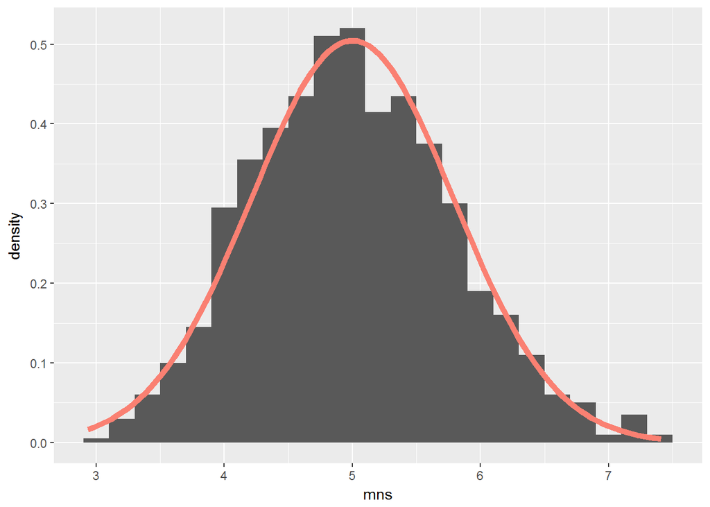

```r
ggplot(df.mns,mapping = aes(x = mns)) +
        geom_histogram(aes(y = ..density..),stat = "bin",binwidth = 0.2)  +
        stat_function(fun = dnorm,color = "salmon",size = 2,
                      args = c( mean = theory.mean,sd = sqrt(theory.var)))
```

We can see that the probobility distribution closely matches to the normal distribution derived by central limit theory.